# practica-2

## UNIVERSIDAD NACIONAL DE SAN AGUSTÍN DE AREQUIPA

### FACULTAD DE PRODUCCIÓN Y SERVICIOS

### ESCUELA PROFESIONAL DE INGENIERÍA EN TELECOMUNICACIONES

[figure not shown]

## TELEFONIA CELULAR

### PRACTICA 2

**Docente:**  
Dr. Alberth Ronal Tamo Calla

**Integrantes:**  
Chavez Ponce Jorge Alberto  
Cana Remache Javier Ricardo  
Neyra Torres Luis Kenny  
Choque Sonco Franco Eleazar  
Chavez Maqui Elmer

AREQUIPA – PERÚ

2024

### Librerias

```python
import math
import numpy as np
import matplotlib.pyplot as plt
from IPython.display import display, Markdown
import pandas as pd
import plotly.graph_objects as go
import plotly.express as px
from matplotlib.patches import Wedge
import matplotlib.colors as colors
```

### Funciones globales

```python
def calcular_distancia(FSPL_dB, f):
    """
    Calcula la distancia en metros dado FSPL en dB y frecuencia en Hz.

    :param FSPL_dB: Pérdida por espacio libre en dB
    :param f: Frecuencia en Hz
    :return: Distancia en kilometros
    """
    d = 10 ** ((FSPL_dB - 20 * math.log10(f) - 32.44) / 20)
    return d


def distance_oh(L_fsl, Lb_area, f, h_b, h_m):
    """Cálculo de la distancia usando la fórmula de Okumura-Hata."""
    return 10 ** (
        (L_fsl - Lb_area - 69.55 - 26.16 * np.log10(f) + 13.82 * np.log10(h_b))
        / (44.9 - 6.55 * np.log10(h_b))
    )
```

## Configuración de Parametros de la antena

```python
# Definir la altura del receptor y su posición
h_rb = 40  # Altura en metros del receptor
h_m = 1.5
p_rb = np.array([0, 0, h_rb])  # Punto receptor fijo (esto es el centro)

# Generar una matriz de posiciones de emisores centrada alrededor del receptor
x, y = np.meshgrid(np.arange(-20, 21), np.arange(-20, 21))
p_em = np.column_stack((x.ravel(), y.ravel(), 1.5 * np.ones(x.size)))  # Emisores a 1.5 m de altura

# Restar las coordenadas del receptor a las posiciones del transmisor para centrar
p_em[:, 0:2] += p_rb[0:2]

# Parámetros de transmisión y enlace
Ptx = 42  # Potencia de transmisión en dBm
Gtx = 18  # Máxima ganancia de la antena transmisora en dBm
Grx = 0  # Ganancia de la antena receptora en dBm
f = 900  # Frecuencia en MHz›
Margin = 0  # Margen de enlace en dB
c = 2.998e8  # Velocidad de la luz en m/s
L_pl = 0  # Pérdidas adicionales
L_cerb = 2 + 2  # 2 dB por cables y 2 dB por combinador
s_em = -106 # Sensibilidad del receptor en dBm

G0 = 18 # Ganancia de la antena isotrópica en dB
```

### a. Gráfica de las posiciones de el transmisor y el receptor

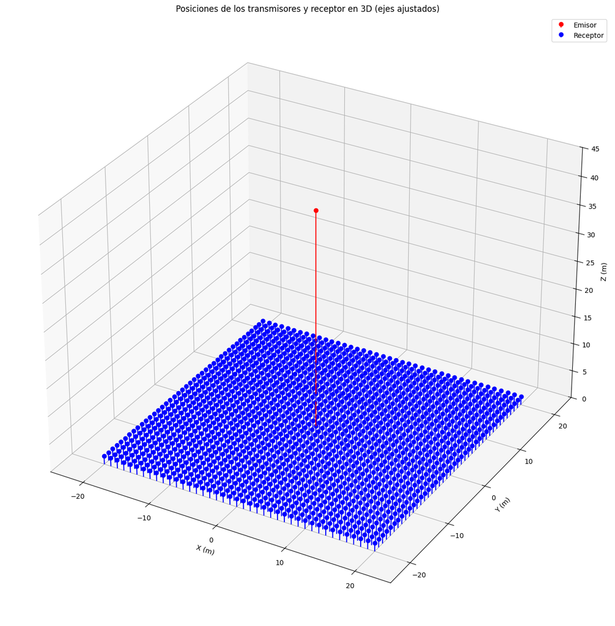

```python
fig = plt.figure(figsize=(16, 16))
ax = fig.add_subplot(111, projection='3d')

# Separación de ejes ajustada para que los puntos se vean más separados
ax.stem([p_rb[0]], [p_rb[1]], [p_rb[2]], linefmt='r-', markerfmt='ro', basefmt=' ', label='Emisor')
ax.stem(p_em[:, 0], p_em[:, 1], p_em[:, 2], linefmt='b-', markerfmt='bo', basefmt=' ', label='Receptor')

# Ajustar los límites de los ejes para una mejor visualización
ax.set_xlim(-25, 25)
ax.set_ylim(-25, 25)
ax.set_zlim(0, 45)

# Etiquetas y título
ax.set_xlabel('X (m)')
ax.set_ylabel('Y (m)')
ax.set_zlabel('Z (m)')
ax.set_title('Posiciones de los transmisores y receptor en 3D (ejes ajustados)')

plt.grid(True)
plt.legend()
plt.show()
```

### b. Cálculo de la distancia, perdida por espacio libre, perdida total y potencia recibida de cada usuario

```python
# Calcular la distancia entre cada transmisor y el receptor
d = np.sqrt(np.sum((p_em - p_rb) ** 2, axis=1))

# Cálculo vectorizado de las pérdidas en el espacio libre (L_fsl)
L_fsl = 20 * np.log10(d) + 20 * np.log10(f) + 20 * np.log10(4 * np.pi / c)
# Cálculo vectorizado de las pérdidas totales (L)
L_total = L_fsl + L_pl + Margin
# Cálculo vectorizado de la potencia recibida (Prx)
Prx = Ptx + Gtx - L_total + Grx

# Mostrar las primeras 10 potencias recibidas
markdown_output_prx = "# Resultados para las primeras 10 potencias recibidas\n\n"
markdown_output_prx += (
    "|Usuario| Distancia (km) | L_fsl (dB) | L_total (dB) | Potencia Recibida (dBm) |\n"
)
markdown_output_prx += (
    "|-------|----------------|------------|--------------|-------------------------|\n"
)

# Generar las filas de la tabla con los resultados
for i in range(10):
    markdown_output_prx += f"| {i+1} | {d[i]:.4f} | {L_fsl[i]:.4f} | {L_total[i]:.2f} | {Prx[i]:.2f} |\n"

# Mostrar la tabla
display(Markdown(markdown_output_prx))
```

Resultados para las primeras 10 potencias recibidas

| Usuario | Distancia (km) | L_fsl (dB) | L_total (dB) | Potencia Recibida (dBm) |
| --- | --- | --- | --- | --- |
| 1 | 47.7729 | -54.8840 | -54.88 | 114.88 |
| 2 | 47.3630 | -54.9588 | -54.96 | 114.96 |
| 3 | 46.9707 | -55.0310 | -55.03 | 115.03 |
| 4 | 46.5967 | -55.1005 | -55.10 | 115.10 |
| 5 | 46.2412 | -55.1670 | -55.17 | 115.17 |
| 6 | 45.9048 | -55.2304 | -55.23 | 115.23 |
| 7 | 45.5878 | -55.2906 | -55.29 | 115.29 |
| 8 | 45.2907 | -55.3474 | -55.35 | 115.35 |
| 9 | 45.0139 | -55.4007 | -55.40 | 115.40 |
| 10 | 44.7577 | -55.4502 | -55.45 | 115.45 |

#### Grafica de la potencia recibida

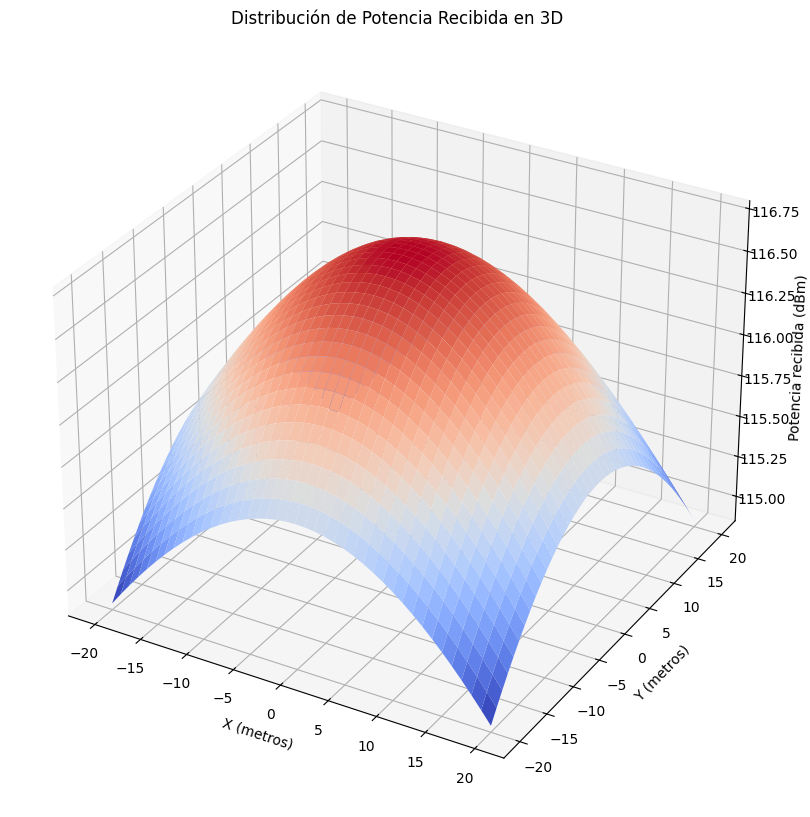

```python
# Crear una gráfica 3D para la potencia recibida
fig = plt.figure(figsize=(10, 12))
ax = fig.add_subplot(111, projection='3d')

# Reshapear la potencia para graficar
Prx_reshaped = Prx.reshape(x.shape)

# Graficar superficie de potencia recibida
ax.plot_surface(x, y, Prx_reshaped, cmap='coolwarm', edgecolor='none')

# Configuraciones de la gráfica
ax.set_xlabel('X (metros)')
ax.set_ylabel('Y (metros)')
ax.set_zlabel('Potencia recibida (dBm)')
ax.set_title('Distribución de Potencia Recibida en 3D')

plt.show()
```

#### Calculo de la perdida maxima por el emisor

```python
# Calculamos la perdida maxima por emisor
L_max = Ptx + Gtx + Grx - s_em
print("La perdida maxima por emisor es:", L_max, "dB")

# Calculamos para que distancia se dio la perdida maxima con la funcion calcular_distancia
d_max = calcular_distancia(L_max, f)

# Distancia en kilometros
print(f'La distancia es: {d_max} km')

# Ahora si le agregamos las otras perdidas tenemos lo siguiente
L_fsl_max = L_max - L_pl - L_cerb - Margin
print("La perdida maxima por emisor con la perdida en el combinador y cable es:", L_fsl_max, "dB")

# Calculamos para que distancia se dio la perdida maxima con la funcion calcular_distancia
d_max = calcular_distancia(L_fsl_max, f)

# Distancia en kilometros
print(f'La distancia es: {d_max} km')
```

```
La perdida maxima por emisor es: 166 dB
La distancia es: 5293.677631171281 km
La perdida maxima por emisor con la perdida en el combinador y cable es: 162 dB
La distancia es: 3340.0847806980332 km
```

## Aplicación de la Recomendación ITU F.1336 para el patrón de radiación de la antena omnidireccional

## Ecuaciones de Ganancia de la Antena

### Fórmula de Ganancia

$$ G(\theta) = \begin{cases} G_0 - 12 \left( \frac{\theta}{\theta_3} \right)^2 & \text{para } 0 \leq |\theta| < \theta_4 \\ G_0 - 12 + 10 \log(k + 1) & \text{para } \theta_4 \leq |\theta| < \theta_3 \\ G_0 - 12 + 10 \log \left[ \left( \frac{|\theta|}{\theta_3} \right)^{-1.5} + k \right] & \text{para } \theta_3 \leq |\theta| \leq 90^\circ \end{cases} \tag{1a} $$

### Definición de los parámetros:

$$ \theta_3 = 107.6 \times 10^{-0.1 G_0} \tag{1b} $$

$$ \theta_4 = \theta_3 \sqrt{1 - \frac{1}{1.2} \log(k + 1)} \tag{1c} $$

```python
# Calcular la ganancia en función de theta
G_0 = 18  # Máxima ganancia en el plano acimutal (dBi)
k = 0  # Parámetro de aumento de lóbulos laterales
theta_3 = 107.6 * 10 ** (-0.1 * G_0)
theta_4 = theta_3 * np.sqrt(1 - np.log10(k + 1) / 1.2)

def calculate_G(theta, G_0, k, theta_3, theta_4):
    theta_abs = np.abs(theta)
    if theta_abs < theta_4:
        return G_0 - 12 * (theta_abs / theta_3) ** 2
    elif theta_abs < theta_3:
        return G_0 - 12 + 10 * np.log10(k + 1)
    elif theta_abs <= 90:
        return G_0 - 12 + 10 * np.log10((theta_abs / theta_3) ** -1.5 + k)
    else:
        return -100  # Valor arbitrario para ángulos fuera de rango
```

### Calculo de los angulos para cada usuario con un angulo de depresion de 2º

```python
# Cálculo de d_max
d_max = 10 ** ((L_max - 20 * np.log10(f) - 92.5) / 20)

# Diferencia de altura entre el receptor y los transmisores
delta_h = p_rb[2] - p_em[:, 2]  # Diferencia entre la altura del receptor y de cada transmisor

# Distancia horizontal entre el receptor y cada transmisor (plano XY)
d_horizontal = np.sqrt((p_em[:, 0] - p_rb[0])**2 + (p_em[:, 1] - p_rb[1])**2)

# Cálculo del ángulo de elevación en grados con 2 grados de depresión
theta_elev = np.degrees(np.arctan2(delta_h, d_horizontal)) - 2

# Hallar beta para calcular el ángulo de elevación
beta = 90 - theta_elev

# Cálculo de la ganancia para cada usuario usando los ángulos de elevación
G_users = np.array([calculate_G(theta, G_0, k, theta_3, theta_4) for theta in theta_elev])

# Generar una tabla de Markdown para los resultados de los primeros 5 usuarios
markdown_output = "# Cálculo de Ganancias para los Usuarios\n\n"
markdown_output += "## Primeros 5 ángulos de elevación y sus ganancias\n\n"
markdown_output += "| Usuario | Ángulo de elevación (β) | Ángulo theta (θ) | Ganancia (dBi) |\n"
markdown_output += "|---------|--------------------------|------------------|----------------|\n"

# Generar las filas de la tabla con los resultados
for i in range(5):
    markdown_output += f"| {i+1} | {beta[i]:.2f}° | {theta_elev[i]:.2f}° | {G_users[i]:.2f} dBi |\n"

# Mostrar el markdown generado
display(Markdown(markdown_output))
```

Cálculo de Ganancias para los Usuarios

Primeros 5 ángulos de elevación y sus ganancias

| Usuario | Ángulo de elevación (β) | Ángulo theta (θ) | Ganancia (dBi) |
| --- | --- | --- | --- |
| 1 | 38.30° | 51.70° | -16.22 dBi |
| 2 | 37.62° | 52.38° | -16.31 dBi |
| 3 | 36.95° | 53.05° | -16.39 dBi |
| 4 | 36.29° | 53.71° | -16.47 dBi |
| 5 | 35.63° | 54.37° | -16.55 dBi |

## Modelo de Okumura Hata

### 1) Para áreas urbanas:

- a. Para ciudades pequeñas o medianas:

$$ a(h_m) = \left( 1.1 \log f - 0.7 \right) h_m - \left( 1.56 \log f - 0.8 \right) \tag{2} $$

Donde:

$$1 \leq h_m \leq 10 \, \text{m} $$

- b. Para ciudades grandes:

$$ a(h_m) = \begin{cases} 8.29 \left( \log 1.54 h_m \right)^2 - 1.1 & \text{para } f \leq 200 \, \text{MHz} \\ 3.2 \left( \log 11.75 h_m \right)^2 - 4.97 & \text{para } f \geq 400 \, \text{MHz} \end{cases} \tag{3} $$

### 2) Para áreas suburbanas:

$$ L_b = L_b (\text{urban}) - 2 \left[ \log \left( \frac{f}{28} \right) \right]^2 - 5.4 \tag{4} $$

### 3) Para áreas rurales:

$$ L_b = L_b (\text{urban}) - 4.78 \log(f)^2 + 18.33 \log(f) - 40.94 \tag{5} $$

```python
# Definir las fórmulas
def a_hm_small_medium_city(f, h_m):
    """Factor de corrección a(h_m) para ciudades pequeñas o medianas."""
    return (1.1 * np.log10(f) - 0.7) * h_m - (1.56 * np.log10(f) - 0.8)


def a_hm_large_city(f, h_m):
    """Factor de corrección a(h_m) para ciudades grandes."""
    if f <= 200:
        return 8.29 * (np.log10(1.54 * h_m)) ** 2 - 1.1
    elif f >= 400:
        return 3.2 * (np.log10(11.75 * h_m)) ** 2 - 4.97
    else:
        raise ValueError(
            "La fórmula para ciudades grandes solo se aplica a f <= 200 MHz o f >= 400 MHz"
        )


def urban_loss(f, h_b, h_m, d_m, large_city=False):
    """Pérdida de propagación en áreas urbanas."""
    if large_city:
        a_hm = a_hm_large_city(f, h_m)
    else:
        a_hm = a_hm_small_medium_city(f, h_m)

    return (
        69.55
        + 26.16 * np.log10(f)
        - 13.82 * np.log10(h_b)
        - a_hm
        + (44.9 - 6.55 * np.log10(h_b)) * np.log10(d_m)
    )


def suburban_loss(f, Lb_urban):
    """Pérdida de propagación en áreas suburbanas."""
    return Lb_urban - 2 * (np.log10(f / 28)) ** 2 - 5.4


def rural_loss(f, Lb_urban):
    """Pérdida de propagación en áreas rurales."""
    return Lb_urban - 4.78 * (np.log10(f)) ** 2 + 18.33 * np.log10(f) - 40.94
```

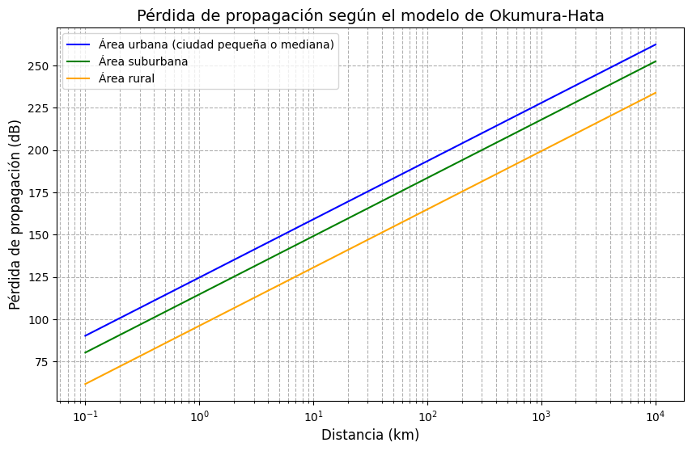

```python
d_m_range = np.logspace(-1, 4, 400)
# Cálculo de la pérdida en área urbana (ciudad pequeña o mediana)
# Calcular las pérdidas para cada tipo de área
Lb_urban = urban_loss(f, h_rb, h_m, d_m_range, large_city=False)
Lb_suburban = suburban_loss(f, Lb_urban)
Lb_rural = rural_loss(f, Lb_urban)

# Grafica de las pérdidas en función de la distancia
plt.figure(figsize=(10, 6))
plt.plot(
    d_m_range, Lb_urban, label="Área urbana (ciudad pequeña o mediana)", color="blue"
)
plt.plot(d_m_range, Lb_suburban, label="Área suburbana", color="green")
plt.plot(d_m_range, Lb_rural, label="Área rural", color="orange")

# Configuración de la gráfica
plt.xscale("log")
plt.yscale("linear")
plt.xlabel("Distancia (km)", fontsize=12)
plt.ylabel("Pérdida de propagación (dB)", fontsize=12)
plt.title("Pérdida de propagación según el modelo de Okumura-Hata", fontsize=14)
plt.grid(True, which="both", ls="--")
plt.legend()
plt.show()
```

## Calculos de las distancias maximas segun el modelo Okumura-Hata

```python
Lb_urban = urban_loss(f, h_rb, h_m, 1)  # Se calcula en base a una distancia de 1 km
Lb_suburban = suburban_loss(f, Lb_urban)
Lb_rural = rural_loss(f, Lb_urban)

# Calcular las distancias máximas usando la pérdida de espacio libre como límite
d_urban_max = distance_oh(L_fsl_max, 0, f, h_rb, h_m)  # Urbana: no hay corrección adicional
d_suburban_max = distance_oh(L_fsl_max, Lb_suburban - Lb_urban, f, h_rb, h_m)  # Suburbana
d_rural_max = distance_oh(L_fsl_max, Lb_rural - Lb_urban, f, h_rb, h_m)  # Rural

# Resultados
markdown_output = "# Resultados de Distancias Máximas\n\n"
markdown_output += "| Área | Distancia Máxima (km) |\n"
markdown_output += "|------|-----------------------|\n"
markdown_output += f"| Urbana | {d_urban_max:.2f} |\n"
markdown_output += f"| Suburbana | {d_suburban_max:.2f} |\n"
markdown_output += f"| Rural | {d_rural_max:.2f} |\n"

display(Markdown(markdown_output))
```

Resultados de Distancias Máximas

| Área | Distancia Máxima (km) |
| --- | --- |
| Urbana | 12.14 |
| Suburbana | 23.62 |
| Rural | 81.82 |

## Calculo de los radios segun la distancia maxima de la zona segun el modelo Okumura-Hata

```python
# Hallando R_max por pitagoras
# Convertir h_rb a km
h_b_km = h_rb / 1000
# Calcular R_max
r_max_rural = np.sqrt(d_rural_max ** 2 + h_b_km ** 2)
r_max_urban = np.sqrt(d_urban_max ** 2 + h_b_km ** 2)
r_max_suburban = np.sqrt(d_suburban_max ** 2 + h_b_km ** 2)

# Resultados
markdown_output = "# Resultados de R_max\n\n"
markdown_output += "| Área | R_max (km) |\n"
markdown_output += "|------|------------|\n"
markdown_output += f"| Urbana | {r_max_urban:.2f} |\n"
markdown_output += f"| Suburbana | {r_max_suburban:.2f} |\n"
markdown_output += f"| Rural | {r_max_rural:.2f} |\n"

display(Markdown(markdown_output))
```

Resultados de R_max

| Área | R_max (km) |
| --- | --- |
| Urbana | 12.14 |
| Suburbana | 23.62 |
| Rural | 81.82 |

## Calculo y grafica de los emisores dentro del radio de cobertura de la antena

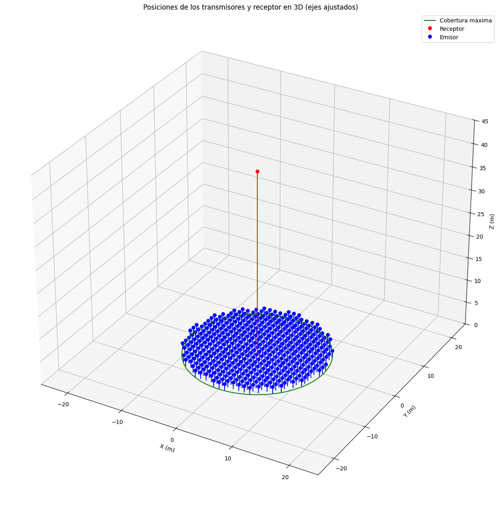

```
emisores_dentro [[ -1.  -12.    1.5]
 [  0.  -12.    1.5]
 [  1.  -12.    1.5]
 ...
 [ -1.   12.    1.5]
 [  0.   12.    1.5]
 [  1.   12.    1.5]]
```

```python
# Calcular las distancias entre cada emisor y el receptor
distancias = np.sqrt((p_em[:, 0] - p_rb[0])**2 + (p_em[:, 1] - p_rb[1])**2)

# Filtrar emisores que están dentro del radio máximo
r_max = r_max_urban  # Definir un radio de cobertura máximo en metros (ajústalo según tus necesidades)
emisores_dentro = p_em[distancias <= r_max]

# Eliminar los emisores que están fuera del radio de cobertura máximo
emisores_fuera = p_em[distancias > r_max]

# Graficar los emisores y receptor en 3D usando stem
fig = plt.figure(figsize=(16, 16))
ax = fig.add_subplot(111, projection='3d')

# Graficar el receptor
ax.stem([p_rb[0]], [p_rb[1]], [p_rb[2]], linefmt='r-', markerfmt='ro', basefmt=' ', label='Receptor')

# Graficar emisores dentro del radio de cobertura
ax.stem(emisores_dentro[:, 0], emisores_dentro[:, 1], emisores_dentro[:, 2], linefmt='b-', markerfmt='bo', basefmt=' ', label='Emisor')

# Ajustar los límites de los ejes para una mejor visualización
ax.set_xlim(-25, 25)
ax.set_ylim(-25, 25)
ax.set_zlim(0, 45)

# Dibujar el círculo de cobertura máxima en el plano XY
theta = np.linspace(0, 2 * np.pi, 100)
x_circulo = r_max * np.cos(theta)
y_circulo = r_max * np.sin(theta)
ax.plot(x_circulo, y_circulo, 0, color='g', label='Cobertura máxima')

# Etiquetas y título
ax.set_xlabel('X (m)')
ax.set_ylabel('Y (m)')
ax.set_zlabel('Z (m)')
ax.set_title('Posiciones de los transmisores y receptor en 3D (ejes ajustados)')

plt.grid(True)
plt.legend()
plt.show()

print("emisores_dentro", emisores_dentro)
```

```python
# Definir el área de cobertura en kilómetros (100 km x 100 km)
area_size = 100.0  # Área en kilómetros

r_max = r_max_urban

# Parámetros de la cuadrícula hexagonal
grid_spacing = 2.39 * r_max * np.sqrt(3)/2  # Espaciado entre los centros de los círculos (0.866 = sqrt(3)/2)

# Generar una cuadrícula hexagonal de posiciones de emisores
x_range = np.arange(-area_size/2, area_size/2 + grid_spacing, grid_spacing)
y_range = np.arange(-area_size/2, area_size/2 + grid_spacing * 0.75, grid_spacing * 0.75)

emisores = []
for i, x in enumerate(x_range):
    for j, y in enumerate(y_range):
        if j % 2 == 0:
            x_pos = x  # Filas pares sin desplazamiento
        else:
            x_pos = x + grid_spacing / 2  # Filas impares desplazadas la mitad del espaciado
        # Filtrar los emisores que están dentro o ligeramente fuera del área rectangular para rellenar huecos
        if -area_size/2 <= x_pos <= area_size/2 + grid_spacing/2 and -area_size/2 <= y <= area_size/2:
            emisores.append([x_pos, y])

emisores = np.array(emisores)

# Crear la figura
fig = go.Figure()

# Añadir los emisores como puntos
fig.add_trace(go.Scatter(
    x=emisores[:, 0],
    y=emisores[:, 1],
    mode='markers',
    marker=dict(size=8, color='blue'),
    name='Antenas'
))

# Añadir los círculos de cobertura de los emisores
theta = np.linspace(0, 2 * np.pi, 100)
for emisor in emisores:
    x_circulo = emisor[0] + r_max * np.cos(theta)
    y_circulo = emisor[1] + r_max * np.sin(theta)
    fig.add_trace(go.Scatter(
        x=x_circulo,
        y=y_circulo,
        mode='lines',
        line=dict(color='green', dash='dash'),
        showlegend=False
    ))

# Dibujar el rectángulo que representa los márgenes del área de cobertura
rect_x = [-area_size/2, area_size/2, area_size/2, -area_size/2, -area_size/2]
rect_y = [-area_size/2, -area_size/2, area_size/2, area_size/2, -area_size/2]

fig.add_trace(go.Scatter(
    x=rect_x,
    y=rect_y,
    mode='lines',
    line=dict(color='red', width=2),
    name='Margen del área'
))

# Configurar la vista de la gráfica
fig.update_layout(
    title='Cobertura de Emisores en 2D con Márgenes (en km)',
    xaxis_title='X (km)',
    yaxis_title='Y (km)',
    xaxis=dict(scaleanchor="y", scaleratio=1),
    yaxis=dict(),
    legend=dict(x=0, y=1),
    width=800,
    height=800
)


# Ajustar los límites de los ejes
fig.update_xaxes(range=[-area_size/2-30, area_size/2+30])
fig.update_yaxes(range=[-area_size/2-30, area_size/2+30])

fig.show()
```

[output not shown]

## Antena Sectorial

### 1) Para patrones de lóbulos laterales máximos:

- **a. Ecuación principal:**

$$ G(\varphi, \theta) = G_0 + G_{\text{hr}}(x_{\text{h}}) + R \cdot G_{\text{vr}}(x_{\text{v}}) \tag{2a1} $$

donde:

- $G_{\text{hr}}(x_{\text{h}})$: Ganancia relativa de referencia de la antena en el plano azimutal en la dirección normalizada de $(x_{\text{h}}, 0)$ (dB).
- $x_{\text{h}} = \frac{|\varphi|}{\varphi_{3}}$
- $\varphi$: Ángulo azimutal relativo al ángulo de la ganancia máxima en el plano horizontal (grados).
- $\varphi_{3}$: Ancho de banda a -3 dB en el plano azimutal (grados) (generalmente igual al ancho de banda sectorial).
- $G_{\text{vr}}(x_{\text{v}})$: Ganancia relativa de referencia de la antena en el plano de elevación en la dirección normalizada de $(0, x_{\text{v}})$ (dB).
- $x_{\text{v}} = \frac{|\theta|}{\theta_{3}}$
- $R$: Relación de compresión de ganancia horizontal a medida que el ángulo azimutal cambia de $0^\circ$ a $\varphi$, definida como:

$$ R = \frac{G_{\text{hr}}(x_{\text{h}}) - G_{\text{hr}}\left(\frac{180^\circ}{\varphi_{3}}\right)}{G_{\text{vr}}(0) - G_{\text{vr}}\left(\frac{180^\circ}{\varphi_{3}}\right)} \tag{2a2} $$

### 2) Ganancia mínima relativa $G_{180}$:

$$ G_{180} = -12 + 10 \log (1 + 8 k_p) - 15 \log \left( \frac{180^\circ}{\theta_3} \right) \tag{2b1} $$

donde:

- $k_p$: parámetro que ajusta la ganancia mínima relativa para patrones de lóbulos laterales máximos.

#### Casos para $k_p$:

- En antenas típicas: $k_p = 0.7$.
- En antenas con mejor rendimiento de lóbulos laterales: $k_p = 0.7$.

### 3) Ganancia de referencia en el plano azimutal $G_{\text{hr}}(x_{\text{h}})$:

Para $x_{\text{h}} \leq 0.5$:

$$ G_{\text{hr}}(x_{\text{h}}) = -12 x_{\text{h}}^2 \tag{2b2} $$

Otros:

$$ G_{\text{hr}}(x_{\text{h}}) \geq G_{180} \tag{2b2} $$

donde:

- $k_{\text{h}}$: factor de ajuste en el patrón de azimut basado en la potencia de fuga $(0 \leq k_{\text{h}} \leq 1)$.
- $ \lambda_{kh} = 3 \left(1 - 0.5^{-k_h}\right) $

#### Casos para $k_{\text{h}}$:

- En antenas típicas: $k_{\text{h}} = 0.8$.
- En antenas con mejor rendimiento de lóbulos laterales: $k_{\text{h}} = 0.7$.

### 4) Ganancia de referencia en el plano de elevación $G_{\text{vr}}(x_{\text{v}})$:

Para $x_{\text{v}} < x_k$:

$$ G_{\text{vr}}(x_{\text{v}}) = -12 x_{\text{v}}^2 \tag{2b3} $$

Para $x_k \leq x_{\text{v}} < 4$:

$$ G_{\text{vr}}(x_{\text{v}}) = -12 + 10 \log (x_{\text{v}}^{-1.5} + k_{\text{v}}) \tag{2b3} $$

Para $4 \leq x_{\text{v}} < \frac{90^\circ}{\theta_3}$:

$$ G_{\text{vr}}(x_{\text{v}}) = -\lambda_{\text{kv}} - C \log (x_{\text{v}}) \tag{2b3} $$

Para $x_{\text{v}} \geq \frac{90^\circ}{\theta_3}$:

$$ G_{\text{vr}}(x_{\text{v}}) = G_{180} \tag{2b3} $$

donde:

- $k_{\text{v}}$: factor de ajuste en el patrón de elevación basado en la potencia de fuga $(0 \leq k_{\text{v}} \leq 1)$.
- $x_k = \sqrt{1 - 0.36 k_{\text{v}}}$
- $\lambda_{\text{kv}} = 12 - C \log(4) - 10 \log(4^{-1.5} + k_{\text{v}})$
- El factor de inclinación de atenuación $C$ se representa como:

$$ C = \frac{10 \log \left( \frac{ \left( \frac{180^\circ}{\theta_3} \right)^{1.5} \cdot \left( 4^{-1.5} + k_{\text{v}} \right) }{1 + 8 k_p} \right)}{\log \left( \frac{22.5^\circ}{\theta_3} \right)} $$

## Calculo de la ganancia en el plano azimutal y elevacion

```python
# Parametros azimutales
phi_3 = 65  # Ángulo de apertura en acimut (en grados)
theta = np.arange(-180, 180.1, 0.1)  # Ángulos azimutales
kh = 0.7  # Factor de ajuste del diagrama azimutal
lambda_kh = 3 * (1 - 0.5 ** (-kh))  # Cálculo de lambda_kh

# Parametros de elevacion
phi = np.arange(-90, 90.1, 0.1)  # Ángulos de elevación
kv = 0.7  # Factor de ajuste en elevación
theta_3 = 107.6 * 10 ** (-0.1 * G0)

# Parámetros adicionales para el ajuste en elevación
kp = 0.7  # Valor para el ajuste en compresión
```

```python
# Cálculo de Ghr (Ganancia en el plano azimutal)
def Ghr(theta, phi_3, kh, lambda_kh):
    xh = np.abs(theta) / phi_3
    result = np.where(xh <= 0.5, -12 * (xh ** 2),
                      -12 * (xh ** (2 - kh)) - lambda_kh)
    return result
# Definición de Gvr
def Gvr(phi, kv, theta_3, kp):
    C = calculate_C(theta_3, kp, kv)
    lambda_kv = calculate_lambda_kv(C, kv)
    xk = np.sqrt(1 - 0.36 * kv)
    xv = np.abs(phi) / theta_3
    result = np.where(
        xv < xk,
        -12 * (xv ** 2),
        np.where(
            xv < 4,
            -12 + 10 * np.log10(xv ** -1.5 + kv),
            -lambda_kv - C * np.log10(xv)
        )
    )
    result[xv >= (90 / theta_3)] = -lambda_kv - C * np.log10(90 / theta_3)
    return result
# Cálculo de lambda_kv
def calculate_lambda_kv(C, kv):
    return 12 - C * np.log10(4) - 10 * np.log10(4 ** -1.5 + kv)

# Cálculo de C
def calculate_C(theta_3, kp, kv):
    num = 10 * np.log10(((180 / theta_3) ** 1.5) * (4 ** -1.5 + kv) / (1 + 8 * kp))
    denom = np.log10(22.5 / theta_3)
    return num / denom

# Cálculo de la relación de compresión R (Relación entre ganancia acimutal y elevacional)
def R(theta, phi_3, kv):
    Ghr_180 = Ghr(180, phi_3, kh, lambda_kh)
    Gvr_0 = Ghr(0, kv, theta_3, kp)
    Gvr_180 = Ghr(180, kv, theta_3, kp)
    return (Ghr(theta, phi_3, kh, lambda_kh) - Ghr_180) / (Gvr_0 - Gvr_180)
```

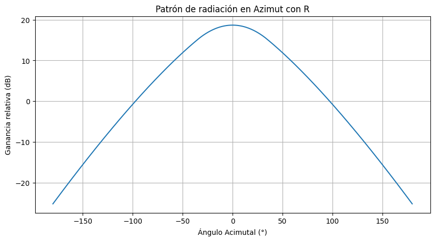

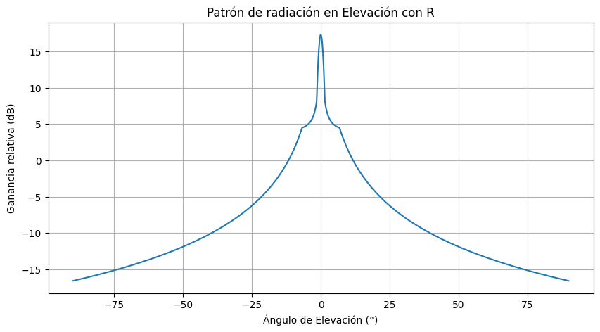

```python
# Vectorizar las funciones
Ghr_vectorized = np.vectorize(Ghr)
Gvr_vectorized = np.vectorize(Gvr)

# Calcular los valores de Ghr y Gvr para cada ángulo
Ghr_values = Ghr_vectorized(theta, phi_3, kh, lambda_kh)
Gvr_values = Gvr_vectorized(phi, kv, theta_3, kp)

# Cálculo de la relación R
R_value_azimut = R(theta, phi_3, kv)  # Para el plano de azimut
R_value_elevacion = R(phi, phi_3, kv)  # Para el plano de elevación

# Calcular G total incluyendo R
G_total_acimut = G0 + Ghr_values + R_value_azimut
G_total_elevacion = G0 + Gvr_values - R_value_elevacion

# Graficar el patrón de radiación en Azimut
plt.figure(figsize=(10, 5))
plt.plot(theta, G_total_acimut)
plt.title("Patrón de radiación en Azimut con R")
plt.xlabel("Ángulo Acimutal (°)")
plt.ylabel("Ganancia relativa (dB)")
plt.grid(True)
plt.show()

# Graficar el patrón de radiación en Elevación
plt.figure(figsize=(10, 5))
plt.plot(phi, G_total_elevacion)
plt.title("Patrón de radiación en Elevación con R")
plt.xlabel("Ángulo de Elevación (°)")
plt.ylabel("Ganancia relativa (dB)")
plt.grid(True)
plt.show()
```

## Distribucion de los sectores en la celda de telefonia celular

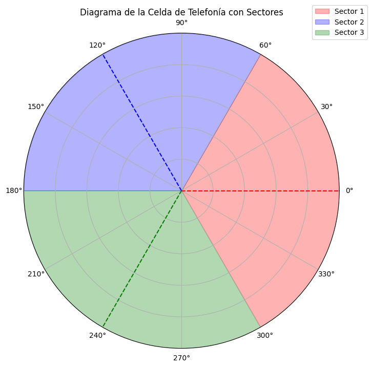

```python
# Parámetros de la celda de telefonía
n_sectors = 3  # Número de sectores
open_sector = 120  # Apertura de cada sector en grados
cell_radius = 100  # Radio de la celda (arbitrario para graficar)
colors_sector = ['red', 'blue', 'green']  # Colores para cada sector

# Crear la figura en coordenadas polares
fig, ax = plt.subplots(figsize=(8, 8), subplot_kw={'projection': 'polar'})

# Dibujar cada sector
for i in range(n_sectors):
    # Ángulo central de cada sector
    central_angle = i * (360 / n_sectors)
    theta = np.radians(np.linspace(central_angle - open_sector/2, central_angle + open_sector/2, 100))
    r = np.full_like(theta, cell_radius)

    # Dibujar el sector en el plano polar
    ax.fill_between(theta, 0, r, color=colors_sector[i], alpha=0.3, label=f"Sector {i+1}")

    # Marcar el ángulo central
    ax.plot([np.radians(central_angle), np.radians(central_angle)], [0, cell_radius], color=colors_sector[i], linestyle='--')

# Configurar el gráfico
ax.set_ylim(0, cell_radius)
ax.set_yticklabels([])  # Ocultar las etiquetas radiales
ax.set_xticks(np.radians(np.arange(0, 360, 30)))  # Divisiones cada 30 grados
ax.set_title("Diagrama de la Celda de Telefonía con Sectores")
ax.legend(loc="upper right", bbox_to_anchor=(1.1, 1.1))

plt.show()
```

## Grafica del mapa de calor de la potencia recibida

```python
# Ángulos de orientación de las antenas sectoriales
phi0 = np.array([0, 120, 240])  # Ángulos en grados

cell = 3300
cell_inner = 1000

# Generar una cuadrícula de puntos que representan a los usuarios dentro del círculo
resolution = 1080  # Número de puntos en cada eje
x = np.linspace(-cell, cell, resolution)
y = np.linspace(-cell, cell, resolution)
xv, yv = np.meshgrid(x, y)

# Crear una máscara circular para limitar los puntos al círculo
distance_to_center = np.sqrt(xv**2 + yv**2)
circular_mask = distance_to_center <= cell

# Aplicar la máscara para obtener las coordenadas dentro del círculo
xv_circle = xv[circular_mask]
yv_circle = yv[circular_mask]

# Alturas y diferencias
dz = h_rb - h_m  # Diferencia de altura entre antena y receptor

# Inicializar una matriz para almacenar la potencia recibida máxima
Prx_max = np.full(xv_circle.shape, -np.inf)

# Cálculo de la potencia recibida para cada antena sectorial
for i in range(len(phi0)):
    # Calcular las diferencias en coordenadas
    dx = xv_circle  # Antenas en (0,0)
    dy = yv_circle
    d_horizontal = np.sqrt(dx ** 2 + dy ** 2)
    d = np.sqrt(d_horizontal ** 2 + dz ** 2)
    d = np.maximum(d, 1)  # Evitar logaritmo de cero

    # Calcular ángulos
    phi = np.degrees(np.arctan2(dy, dx))
    phi_rel = phi - phi0[i]
    phi_rel = (phi_rel + 180) % 360 - 180

    theta = np.degrees(np.arctan2(dz, d_horizontal))

    # Calcular las ganancias de la antena
    Ghr_values = Ghr(phi_rel, phi_3, kh, lambda_kh)
    Gvr_values = Gvr(theta, kv, theta_3, kp)
    G_total = G0 + Ghr_values + Gvr_values

    # Calcular pérdidas y potencia recibida
    L_fsl = 20 * np.log10(d) + 20 * np.log10(f) + 32.44
    L_total = L_fsl + L_pl + Margin + L_cerb
    Prx = Ptx + G_total - L_total + Grx

    # Actualizar la potencia máxima recibida
    Prx_max = np.maximum(Prx_max, Prx)

# Aplicar máscara para valores por debajo de la sensibilidad
Prx_plot = np.where(Prx_max >= s_em, Prx_max, np.nan)

# Crear una matriz para el mapa de calor
Prx_full = np.full(xv.shape, np.nan)
Prx_full[circular_mask] = Prx_plot
```

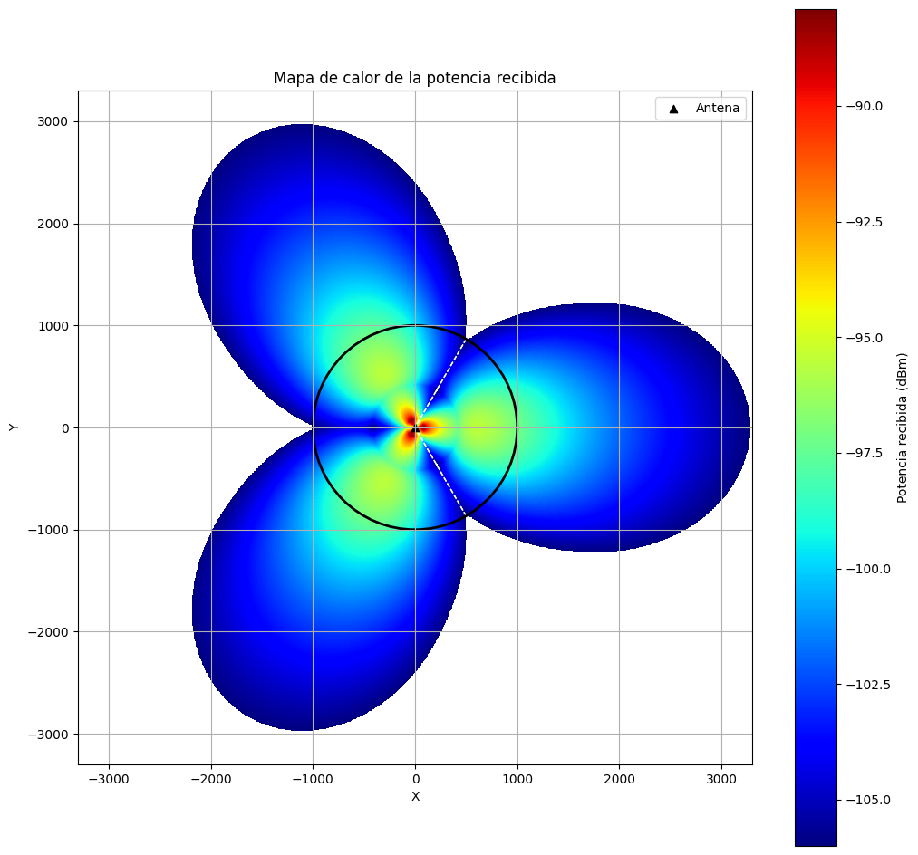

```python
# Graficar el mapa de calor de la potencia recibida
plt.figure(figsize=(12, 12))
plt.imshow(
    Prx_full,
    extent=(x.min(), x.max(), y.min(), y.max()),
    origin='lower',
    cmap='jet',
    norm=colors.Normalize(vmin=np.nanmin(Prx_plot), vmax=np.nanmax(Prx_plot))
)
plt.colorbar(label='Potencia recibida (dBm)')
plt.title('Mapa de calor de la potencia recibida')
plt.xlabel('X')
plt.ylabel('Y')

# Dibujar los sectores como parches
ax = plt.gca()
sectors_colors = ['red', 'green', 'blue']

for i in range(len(phi0)):
    # Crear un parche tipo Wedge (sector circular)
    sector = Wedge(
        center=(0, 0),
        r=cell,
        theta1=phi0[i] - 60,
        theta2=phi0[i] + 60,
        facecolor='none',
        edgecolor='white',
        linestyle='--',
        linewidth=1
    )
    ax.add_patch(sector)

# Dibujar el círculo interno
circle_inner = plt.Circle((0, 0), cell_inner, color='black', fill=False, linewidth=2)
ax.add_artist(circle_inner)

# Marcar la posición de la antena en el centro
plt.scatter(0, 0, color='black', marker='^', label='Antena')

plt.legend()
plt.grid(True)
plt.show()
```